# moma-met-cross

```r
#load packages
library(tidyverse)
```

```r
library(dplyr)
library(ggplot2)
library(forcats)
library(Hmisc)
library(HH)
library(mi)
library(extracat)
library(tm)
library(rapportools)
# set color
mycolor <- "#80593D"
myfill <- "#9FC29F"
```

```r
# load data from moma and met
moma_artists <- read_csv("../data/raw/moma/Artists.csv")
moma_artworks <- read_csv("../data/raw/moma/Artworks.csv")
# 1. Missing data
# 1.1 MOMA
# cut out columns that we dont need

str(moma_artists)
```

```
## Classes 'spec_tbl_df', 'tbl_df', 'tbl' and 'data.frame': 15853 obs. of  9 variables:
##  $ ConstituentID: num  1 2 3 4 5 6 7 9 10 11 ...
##  $ DisplayName  : chr  "Robert Arneson" "Doroteo Arnaiz" "Bill Arnold" "Charles Arnoldi" ...
##  $ ArtistBio    : chr  "American, 1930–1992" "Spanish, born 1936" "American, born 1941" "American, born 1946" ...
##  $ Nationality  : chr  "American" "Spanish" "American" "American" ...
##  $ Gender       : chr  "Male" "Male" "Male" "Male" ...
##  $ BeginDate    : num  1930 1936 1941 1946 1941 ...
##  $ EndDate      : num  1992 0 0 0 0 ...
##  $ Wiki QID     : chr  NA NA NA "Q1063584" ...
##  $ ULAN         : num  NA NA NA 5e+08 NA ...
##  - attr(*, "spec")=
##   .. cols(
##   ..   ConstituentID = col_double(),
##   ..   DisplayName = col_character(),
##   ..   ArtistBio = col_character(),
##   ..   Nationality = col_character(),
##   ..   Gender = col_character(),
##   ..   BeginDate = col_double(),
##   ..   EndDate = col_double(),
##   ..   `Wiki QID` = col_character(),
##   ..   ULAN = col_double()
##   .. )
```

This is a dataset describing 15,853 observations with 9 columns. However, we can quickly notice that some columns are either redundant or seemingly meaningless for exploratory analysis, such as ConstituentID, ArtistBio (which is combining Nationality, BeginDate and EndDate), Wiki QID, ULAN; as a result, we will just go ahead and drop them.

```r
# we first explore the artists dataset, we only include: DisplayName, Nationality, Gender, BeginDate, and EndDate
moma_artists <- moma_artists[c(2,4,5,6,7)]

str(moma_artists)
```

```
## Classes 'tbl_df', 'tbl' and 'data.frame':    15853 obs. of  5 variables:
##  $ DisplayName: chr  "Robert Arneson" "Doroteo Arnaiz" "Bill Arnold" "Charles Arnoldi" ...
##  $ Nationality: chr  "American" "Spanish" "American" "American" ...
##  $ Gender     : chr  "Male" "Male" "Male" "Male" ...
##  $ BeginDate  : num  1930 1936 1941 1946 1941 ...
##  $ EndDate    : num  1992 0 0 0 0 ...
```

Now, we just have 5 columns with the same number of observations: Artist Display Name, Nationality, Gender, Artist Birth Year, Artist Death Year. We will proceed to clean up the datasets and observed the patterns in the missing data.

```r
# quick scan
# We will do a quick scan first:
colSums(is.na(moma_artists))
```

```
## DisplayName Nationality      Gender   BeginDate     EndDate
##           0        2556        3179           0           0
```

From the report, it says that only Nationality and Gender are the columns with missing value. This seems odd as it is nearly impossible for BeginDate (Birth Year) and EndDate (Death Year) to not have any missing data. Thus, we go back and eyeball the dataset. From the process, we realize that the missing values in BeginDate and EndDate columns are denoted as 0 instead NA. That said, we will replace the 0s with NAs.

```r
# clean up BeginDate and EndDate columns
moma_clean <- moma_artists
moma_clean$BeginDate[(moma_clean$BeginDate == 0)] <- NA
moma_clean$EndDate[(moma_clean$EndDate == 0)] <- NA

# now check again
colSums(is.na(moma_clean))
```

```
## DisplayName Nationality      Gender   BeginDate     EndDate
##           0        2556        3179        3791       10779
```

```r
# group the other three columns and see if there is any NAs that are not tracked by NA due to human error while entering the data

nationality_na <- moma_clean %>% group_by(Nationality) %>% dplyr::summarise(Total = dplyr::n()) %>% arrange(Total)

gender_na <- moma_clean %>% group_by (Gender) %>% dplyr::summarise(Total = dplyr::n()) %>% arrange(Total)

name_na <- moma_clean %>% group_by(DisplayName) %>% dplyr::summarise(Total = dplyr::n()) %>% arrange(Total)

# by manually search "unknown" and related keywords in the dataset, we caught on error: NAs in Nationality are also denoted as "nationality unknown"
moma_clean$Nationality[moma_clean$Nationality == "Nationality unknown"] <- NA

# Similarly, with the Name column, there are also some bad format NAs
moma_clean$DisplayName <- tolower(moma_clean$DisplayName)
moma_clean$DisplayName[str_detect(moma_clean$DisplayName, "unknown") == TRUE] <- NA

# with the gender column, we noticed that the biggest problem is with lowercase and upper case; also, since there is only 1 data observation on binary gender, we might consider dropping it later
moma_clean$Gender <- tolower(moma_clean$Gender)

colSums(is.na(moma_clean))
```

```
## DisplayName Nationality      Gender   BeginDate     EndDate
##          53        2736        3179        3791       10779
```

We also checked the other three columns, Display Name, Nationality, and Gender, in case there are some human errors (such as entering the data in the wrong format) that might lead to NAs not being tracked by correctly. In fact, there were some for the Display Name and Nationality columns. Nas in the Display column are denoted with characters spelling out in words. Similarly, NAs in the Nationality column are also denoted in words. After cleaning them up, we uncovered 53 NAs in the Display Name column, 180 NAs in the Nationality column and above is the result of complete missing data values in this dataset. For the Gender column, no NAs are uncovered, but there is upper case and lower case issue such as “male” and “Male”, so we just turn all the gender types to lower case.

The result above is the total sum of all the missing data in this dataset. We will plot a graph to better understand the missing patterns.

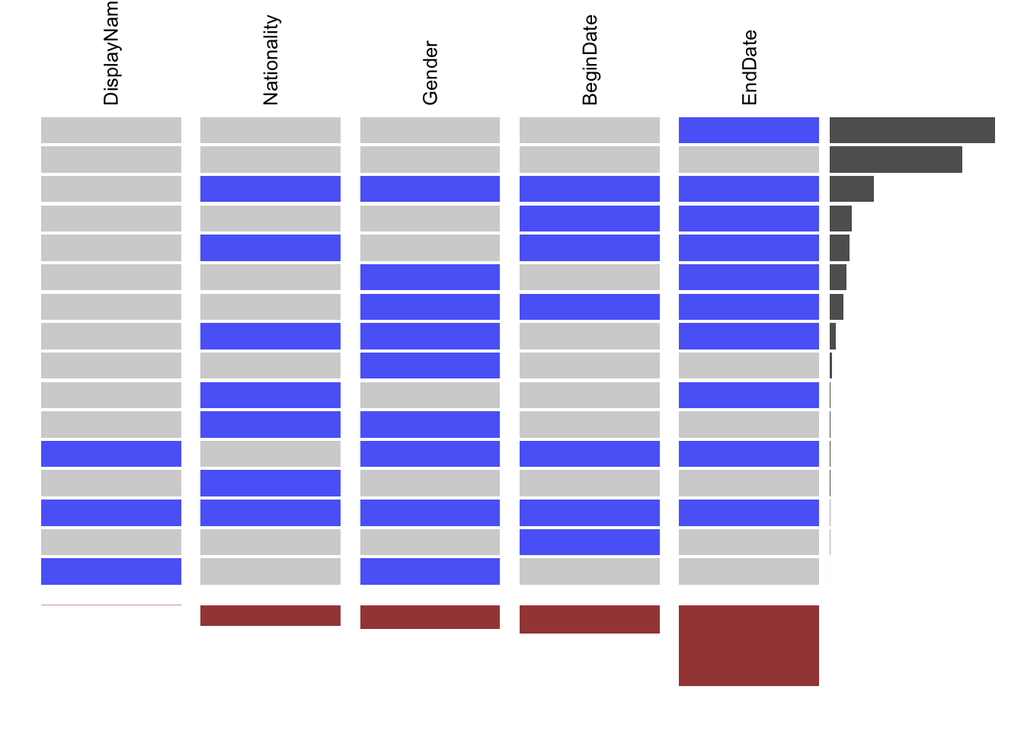

```r
# plot missing patterns
visna(moma_clean, sort = 'r')
```

Concluded from the graph above, most rows are missing just the EndDate column, which means missing the death year of an artist. Not missing any data is the second most common pattern in this dataset. But surprisingly, missing all of the columns (other than Display Name) is the third most common patterns. Thus, there are quite decent amount of rows that we cannot use (since they are missing four of the columns that we want to look into). We will now proceed to explore the dataset while taken into account of the missing patterns.

```r
# First, what is MOMA's preference on Nationality?
moma_org <- moma_clean[2] %>% group_by(Nationality) %>% dplyr::summarise(Frequency = dplyr::n()) %>% arrange(Frequency)

# check the stats
describe(moma_org)
```

```
## moma_org
##
##  2  Variables      127  Observations
## ---------------------------------------------------------------------------
## Nationality
##        n  missing distinct
##      126        1      126
##
## lowest : Afghan     Albanian   Algerian   American   Argentine
## highest: Venezuelan Vietnamese Welsh      Yugoslav   Zimbabwean
## ---------------------------------------------------------------------------
## Frequency
##        n  missing distinct     Info     Mean      Gmd      .05      .10
##      127        0       53    0.986    124.8    225.3      1.0      1.0
##      .25      .50      .75      .90      .95
##      2.0      6.0     44.0    165.0    446.2
##
## lowest :    1    2    3    4    5, highest:  872  880  977 2736 5472
## ---------------------------------------------------------------------------
```

Of the 15,853 observations (including NAs), 95% of the data are less than the frequency of the top 5% of the nationalities, where the cut off is only 446 counts. Thus, we are definitely seeing a long-tail effect, that of the 15,853 observations, most of them are from the same countries on the top 5% list.

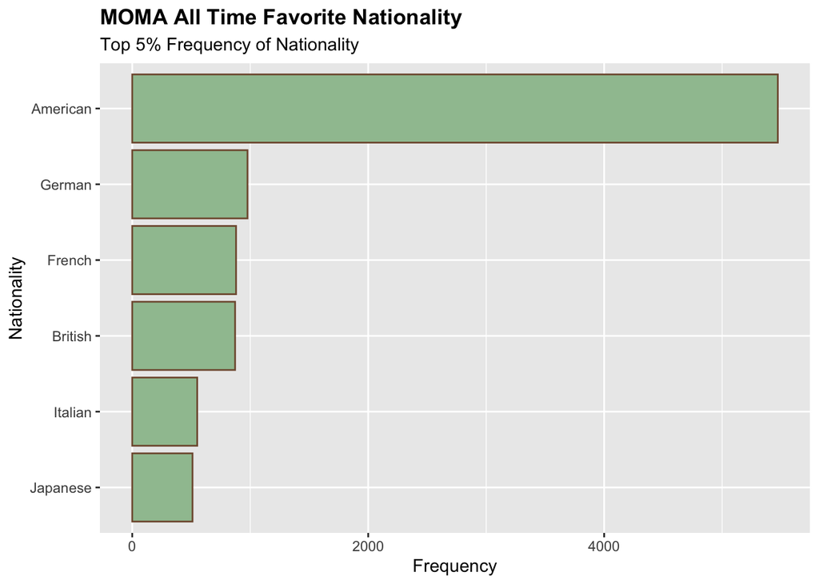

```r
# take the top 5% that can represent the nationality column
moma_org5 <- moma_org %>% group_by (Frequency) %>% filter(Frequency > 446)

# filter out na for now
moma_org5 <- moma_org5 %>% group_by(Nationality) %>% filter(is.na(Nationality) == FALSE)

# frequency of nationality
ggplot(moma_org5, aes(fct_reorder(Nationality, Frequency), Frequency)) +
  geom_bar(stat = "identity") +
  ggtitle("MOMA All Time Favorite Nationality", subtitle = "Top 5% Frequency of Nationality") +
  xlab("Nationality") +
  geom_col(color = mycolor, fill = myfill) +
  coord_flip() +
  theme(plot.title = element_text(face = "bold"))
```

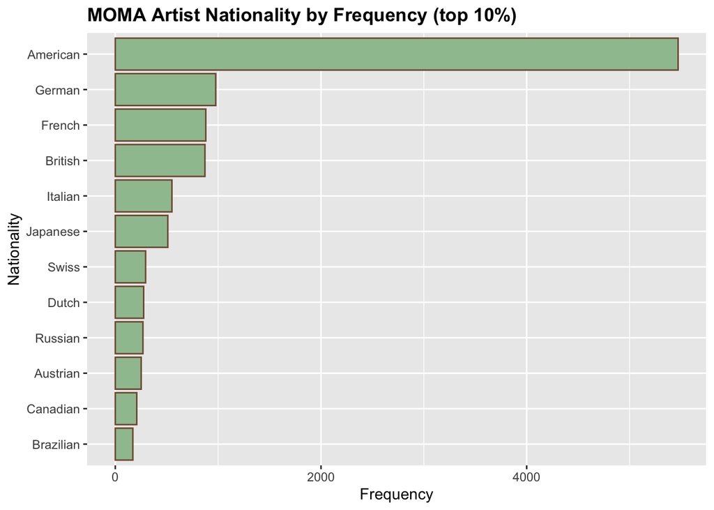

```r
# if by top 10%, which is 165
moma_org10 <- moma_org %>% group_by (Frequency) %>% filter(Frequency > 165)
# filter out NA for now
moma_org10 <- moma_org10 %>% group_by (Nationality) %>% filter(is.na(Nationality)== FALSE)
# frequency of nationality
ggplot(moma_org10, aes(fct_reorder(Nationality, Frequency), Frequency)) +
  geom_bar(stat = "identity") +
  ggtitle("MOMA Artist Nationality by Frequency (top 10%)") +
  xlab("Nationality") +
  geom_col(color = mycolor, fill = myfill) +
  coord_flip() +
  theme(plot.title = element_text(face = "bold"))
```

Thus, we observed that among the 90% of the artworks collected by MOMA (which are 12 countries), 8 are European countries, 2 are North American countries, 1 is South American and 1 is Asian.

```r
# Now, let's check by gender of those top 5%
moma_org5_gender <- moma_clean %>% group_by(Gender, Nationality) %>% dplyr::summarize(Frequency= dplyr::n()) %>% arrange(Frequency) %>% filter(Nationality %in% c("American", "British", "German", "Italian", "Japanese"))
```

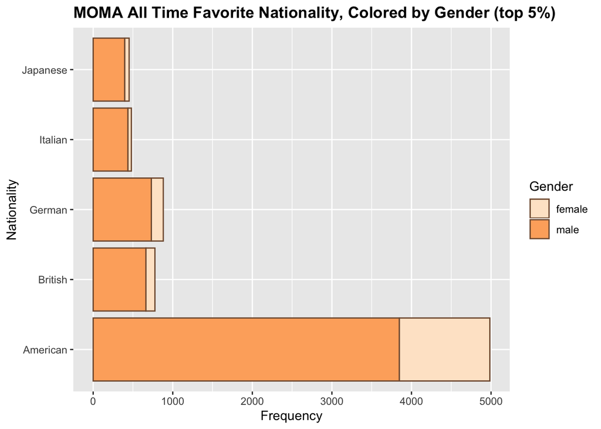

```r
#if exclude NA for now
moma_org5_gender <- moma_org5_gender %>% group_by(Gender) %>% filter(Gender %in% c("female", "male"))
ggplot(moma_org5_gender, aes(Nationality, Frequency, fill = Gender)) +
  geom_bar(stat = "identity") +
  ggtitle("MOMA All Time Favorite Nationality, Colored by Gender (top 5%)") +
  xlab("Nationality") +
  scale_fill_brewer(palette= "Oranges")+
  geom_col(color = mycolor) +
  coord_flip() +
  theme(plot.title = element_text(face = "bold"))
```

```r
# dplyr::ext, we look at Birth Year
moma_birthy <- moma_clean[4] %>% group_by (BeginDate) %>% dplyr::summarize(Frequency= dplyr::n()) %>% arrange(Frequency)
moma_birthy$BeginDate <- as.character(moma_birthy$BeginDate)
# again, check the stats
describe(moma_birthy)
```

```
## moma_birthy
##
##  2  Variables      234  Observations
## ---------------------------------------------------------------------------
## BeginDate
##        n  missing distinct
##      233        1      233
##
## lowest : 1730 1731 1746 1753 1765, highest: 2012 2014 2015 2016 2017
## ---------------------------------------------------------------------------
## Frequency
##        n  missing distinct     Info     Mean      Gmd      .05      .10
##      234        0      105    0.999    67.75    90.84     1.00     2.00
##      .25      .50      .75      .90      .95
##     6.00    22.50    94.25   138.40   153.00
##
## Value          0    50   100   150   200  3800
## Frequency    121    33    42    33     4     1
## Proportion 0.517 0.141 0.179 0.141 0.017 0.004
## ---------------------------------------------------------------------------
```

Again, we take the 95% percentile, and see a similar result, that 95% of the birth years are fewer than 153 counts, which means most of the artists are from similar or identical birh years, which is quite surprising.

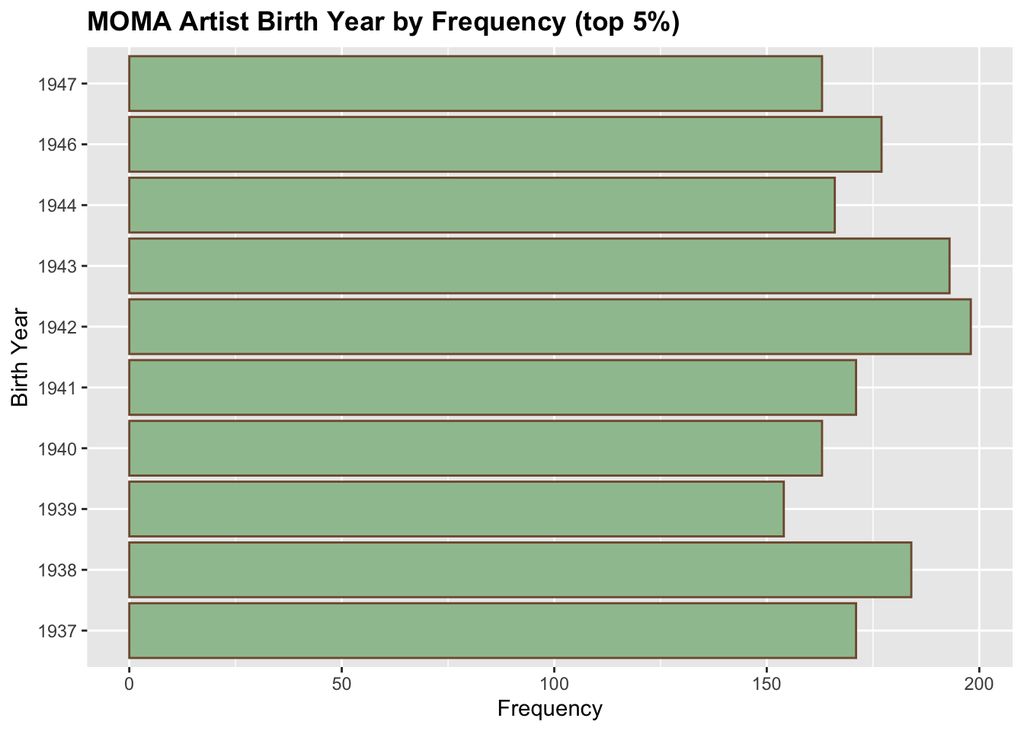

```r
# let's see the top 5%
moma_birthy5 <- moma_birthy %>% group_by(Frequency) %>% filter(Frequency > 153)
# and exclude NA for now
moma_birthy5 <- moma_birthy5 %>% group_by(BeginDate) %>% filter(is.na(BeginDate) == FALSE)
# frequency of birth year
ggplot(moma_birthy5, aes(BeginDate, Frequency)) +
  geom_bar(stat = "identity") +
  ggtitle("MOMA Artist Birth Year by Frequency (top 5%)") +
  xlab("Birth Year") +
  geom_col(color = mycolor, fill = myfill) +
  coord_flip() +
  theme(plot.title = element_text(face = "bold"))
```

We observed that these ten consequentive years (excluding 1945) accounts for the birth year of the artists that are most recognized by MOMA. Perhaps, these ten years really made artists creative :)

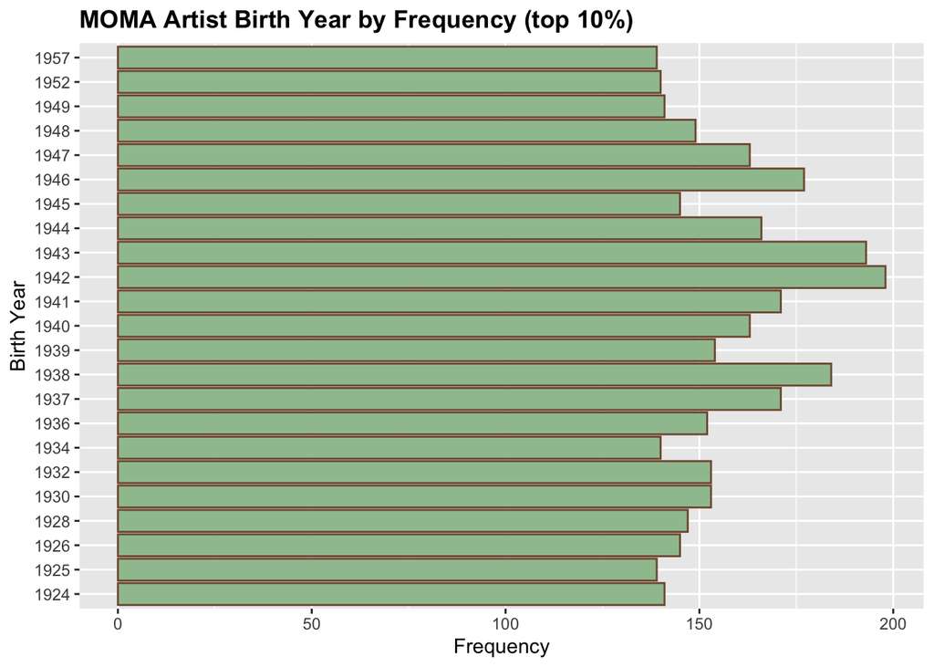

```r
# let's see the top 10%, which is greater than 138
moma_birthy10 <- moma_birthy %>% group_by(Frequency) %>% filter(Frequency > 138)
# and exclude NA for now
moma_birthy10 <- moma_birthy10 %>% group_by(BeginDate) %>% filter(is.na(BeginDate) == FALSE)
# frequency of birth year
ggplot(moma_birthy10, aes(BeginDate, Frequency)) +
  geom_bar(stat = "identity") +
  ggtitle("MOMA Artist Birth Year by Frequency (top 10%)") +
  xlab("Birth Year") +
  geom_col(color = mycolor, fill = myfill) +
  coord_flip() +
  theme(plot.title = element_text(face = "bold"))
```

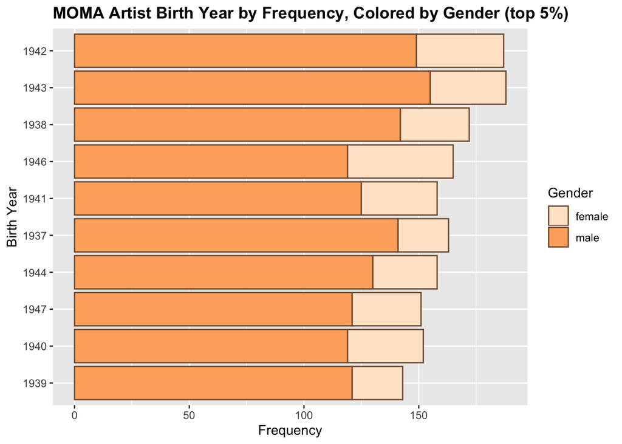

```r
# we plot by gender
moma_birthy5_gender <- moma_clean %>% group_by(Gender, BeginDate) %>% dplyr::summarize(Frequency=dplyr::n())
# just check the top 5%
moma_birthy5_gender$BeginDate <- factor(moma_birthy5_gender$BeginDate, levels = moma_birthy5$BeginDate)
# take out NAs
moma_birthy5_gender <- moma_birthy5_gender %>% group_by(BeginDate) %>% filter( !is.na(BeginDate))
moma_birthy5_gender <- moma_birthy5_gender %>% group_by(Gender) %>% filter(Gender %in% c("female", "male"))
# plot it
ggplot(moma_birthy5_gender, aes(BeginDate, Frequency, fill = Gender)) +
  geom_bar(stat = "identity") +
  ggtitle("MOMA Artist Birth Year by Frequency, Colored by Gender (top 5%)") +
  xlab("Birth Year") +
  scale_fill_brewer(palette= "Oranges")+
  geom_col(color = mycolor) +
  coord_flip() +
  theme(plot.title = element_text(face = "bold"))
```

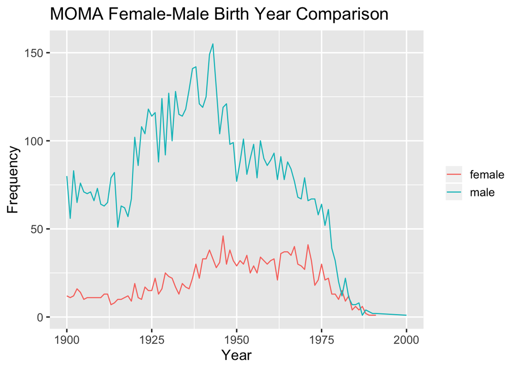

```r
# if plot on time series
moma_birthy_gen_time <- moma_clean %>% group_by(Gender, BeginDate) %>% dplyr::summarize(Frequency=dplyr::n())

moma_birthy_gen_time$BeginDate <- strtoi(moma_birthy_gen_time$BeginDate)

# remove NAs
moma_birthy_gen_time <- moma_birthy_gen_time %>% group_by(Gender) %>% filter(Gender %in% c("female", "male"))
moma_birthy_gen_time <- moma_birthy_gen_time %>% group_by(BeginDate) %>% filter(BeginDate >= 1900)

ggplot(moma_birthy_gen_time, aes(BeginDate, Frequency, color = Gender)) +
  geom_line() +
  ggtitle("MOMA Female-Male Birth Year Comparison") +
  theme_grey(14) +
  theme(legend.title = element_blank()) +
  labs(x = "Year", y = "Frequency")
```

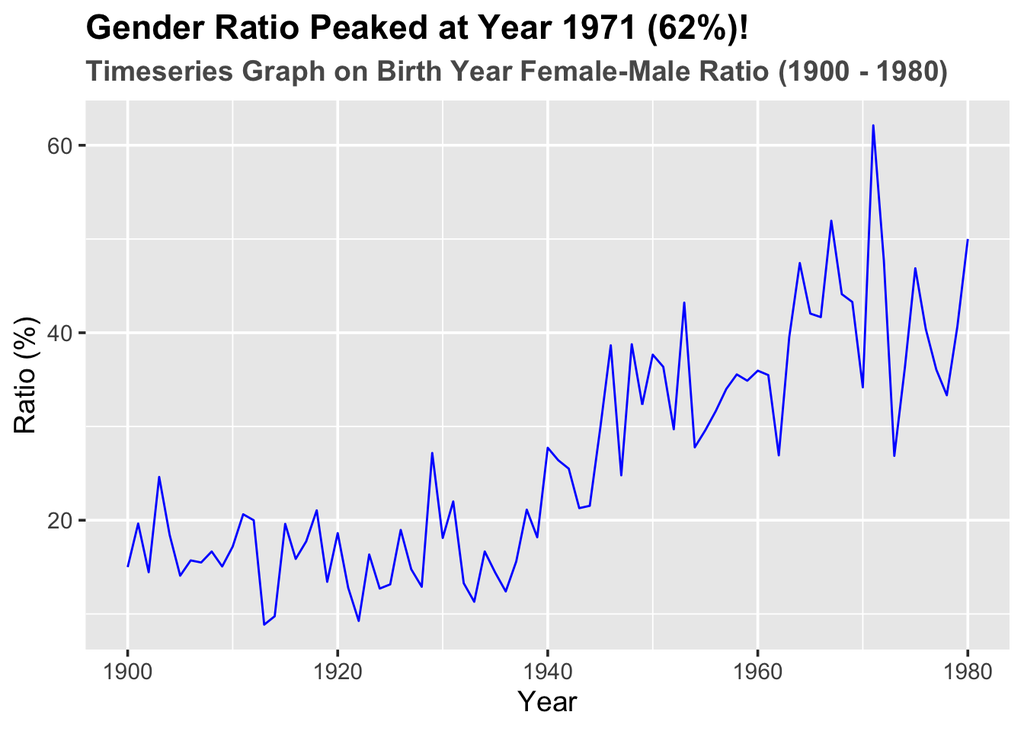

```r
# calculate female-male ratio
moma_birthy_gen_ratio <- moma_clean
moma_birthy_gen_ratio <- moma_birthy_gen_ratio %>% group_by(Gender) %>% filter(Gender %in% c("female", "male"))
moma_birthy_gen_ratio <- moma_birthy_gen_ratio%>% group_by(BeginDate, Gender) %>% dplyr::summarise(Frequency = dplyr::n())
moma_birthy_gen_ratio <- moma_birthy_gen_ratio %>% group_by(BeginDate) %>% filter(BeginDate >= 1900 & BeginDate <= 1980)

moma_birthy_gen_ratio <- moma_birthy_gen_ratio %>% group_by(BeginDate) %>% dplyr::mutate(Ratio = 100*Frequency[Gender=="female"]/Frequency[Gender == "male"])

# plot on ratio
ggplot(moma_birthy_gen_ratio, aes(BeginDate, Ratio)) +
  geom_line(color = "blue") +
  ggtitle("Gender Ratio Peaked at Year 1971 (62%)!", subtitle = "Timeseries Graph on Birth Year Female-Male Ratio (1900 - 1980)") +
  labs(x = "Year", y = "Ratio (%)") +
  theme_grey(14) +
  theme(plot.title = element_text(face = "bold")) +
  theme(plot.subtitle = element_text(face = "bold", color = "grey35")) +
  theme(plot.caption = element_text(color = "grey68"))
```

```r
# Name analysis
moma_artist_name <- moma_clean %>% group_by(BeginDate) %>% filter(BeginDate >= 1937 & BeginDate <= 1947)

# Capitalized for visualization
moma_artist_name$DisplayName <- capitalize(moma_artist_name$DisplayName)

# 1.4.1 On Nationality
# first, a high level pic
# moma_artists_sub_org <- moma_artists_sub %>% group_by(Nationality) %>% dplyr::summarize(Frequency = dplyr::n()) %>% arrange(Frequency)
# NA only takes a small proportion, so we exclude it
# moma_artists_sub_org <- moma_artists_sub_org %>% group_by(Nationality) %>% filter(is.na(Nationality) == FALSE)
```

They collected a lot from American artists. But who are they? Can we tell?

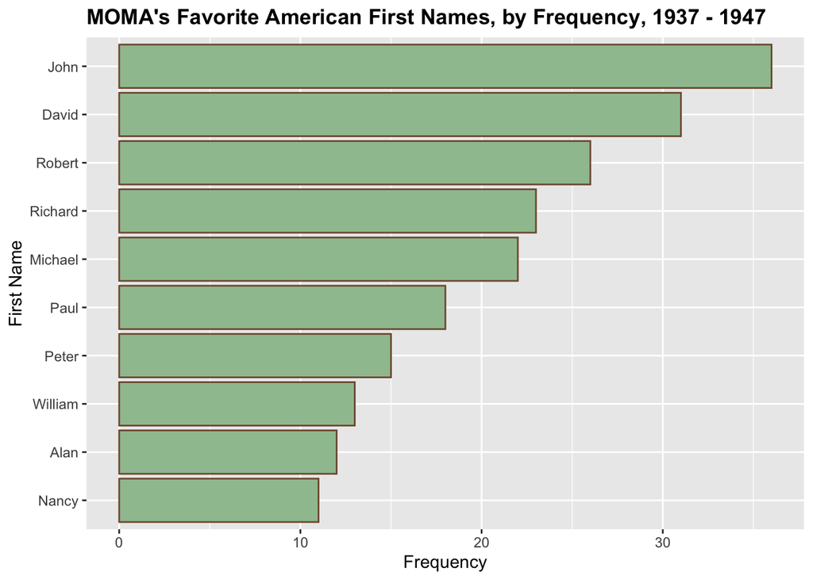

```r
moma_artists_sub_us <- moma_artist_name %>% group_by(Nationality) %>% filter(Nationality == 'American')
first_name_us <- as.data.frame(word(moma_artists_sub_us$DisplayName,1))
colnames(first_name_us) <- 'first_name'
first_name_count <- first_name_us %>% group_by(first_name) %>% dplyr::summarise(Frequency = dplyr::n()) %>% arrange(Frequency)
# first name frequency
ggplot(tail(first_name_count,10), aes(fct_reorder(first_name, Frequency), Frequency)) +
  geom_bar(stat = "identity") +
  ggtitle("MOMA's Favorite American First Names, by Frequency, 1937 - 1947") +
  xlab("First Name") +
  geom_col(color = mycolor, fill = myfill) +
  coord_flip() +
  theme(plot.title = element_text(face = "bold"))
```

[figure not shown]

```r
# let's check last name
last_name_us <- as.data.frame(word(moma_artists_sub_us$DisplayName,-1))
colnames(last_name_us) <- 'last_name'
last_name_count <- last_name_us %>% group_by(last_name) %>% dplyr::summarise(Frequency = dplyr::n()) %>% arrange(Frequency)
# first name frequency
ggplot(tail(last_name_count,10), aes(fct_reorder(last_name, Frequency), Frequency)) +
  geom_bar(stat = "identity") +
  ggtitle("MOMA's Favorite American Last Names, by Frequency, 1937 - 1947") +
  xlab("Last Name") +
  geom_col(color = mycolor, fill = myfill) +
  coord_flip() +
  theme(plot.title = element_text(face = "bold"))
```

```r
# if all
all_us <- moma_clean %>% group_by(Nationality) %>% filter(Nationality == 'American')
first_name_all <- as.data.frame(word(all_us$DisplayName,1))
colnames(first_name_all) <- 'first_name'
first_name_allc <- first_name_all %>% group_by(first_name) %>% dplyr::summarise(Frequency = dplyr::n()) %>% arrange(Frequency)
```

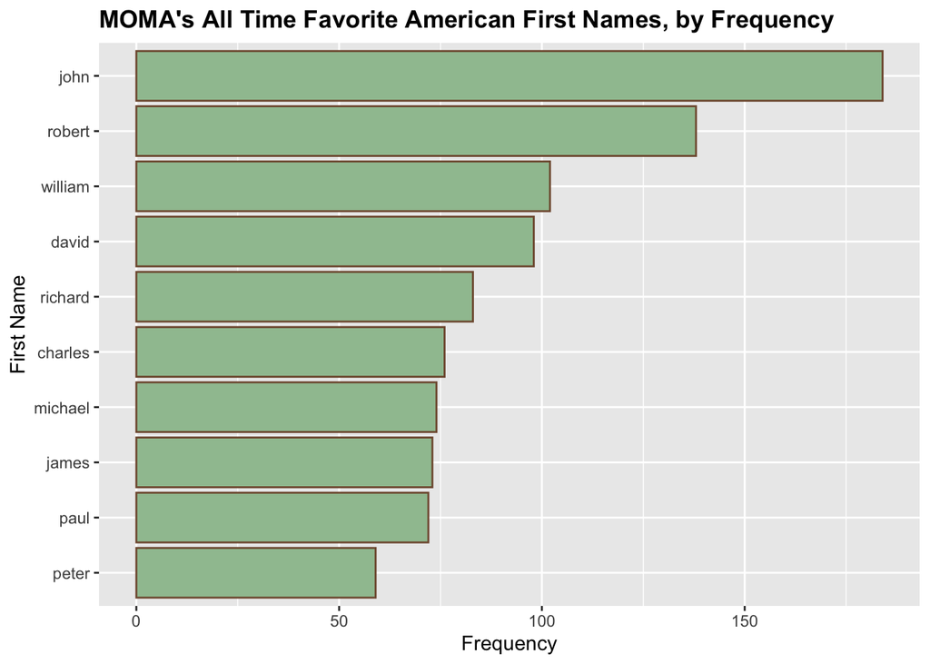

```r
# first name frequency
ggplot(tail(first_name_allc,10), aes(fct_reorder(first_name, Frequency), Frequency)) +
  geom_bar(stat = "identity") +
  ggtitle("MOMA's All Time Favorite American First Names, by Frequency") +
  xlab("First Name") +
  geom_col(color = mycolor, fill = myfill) +
  coord_flip() +
  theme(plot.title = element_text(face = "bold"))
```

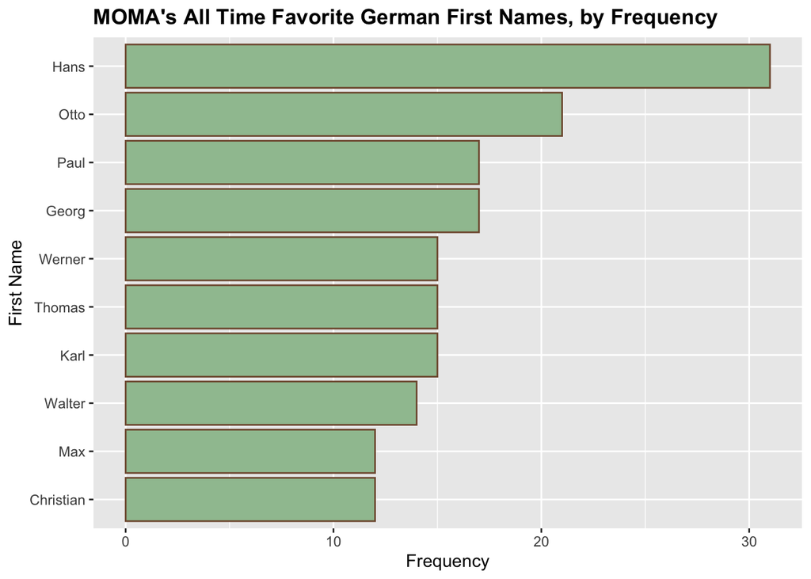

```r
# if all
all_de <- moma_artists %>% group_by(Nationality) %>% filter(Nationality == 'German')
first_name_all_de <- as.data.frame(word(all_de$DisplayName,1))
colnames(first_name_all_de) <- 'first_name'
first_name_allc_de <- first_name_all_de %>% group_by(first_name) %>% dplyr::summarise(Frequency = dplyr::n()) %>% arrange(Frequency)
#first_name_allc_de$first_name <- capitalize(first_name_allc_de$first_name)
# first name frequency
ggplot(tail(first_name_allc_de,10), aes(fct_reorder(first_name, Frequency), Frequency)) +
  geom_bar(stat = "identity") +
  ggtitle("MOMA's All Time Favorite German First Names, by Frequency") +
  xlab("First Name") +
  geom_col(color = mycolor, fill = myfill) +
  coord_flip() +
  theme(plot.title = element_text(face = "bold"))
```

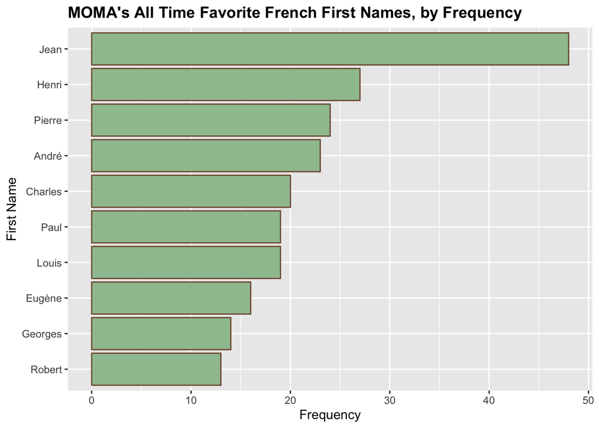

```r
# if all
all_fr <- moma_artists %>% group_by(Nationality) %>% filter(Nationality == 'French')
first_name_all_fr <- as.data.frame(word(all_fr$DisplayName,1))
colnames(first_name_all_fr) <- 'first_name'
first_name_allc_fr <- first_name_all_fr %>% group_by(first_name) %>% dplyr::summarise(Frequency = dplyr::n()) %>% arrange(Frequency)
# first name frequency
ggplot(tail(first_name_allc_fr,10), aes(fct_reorder(first_name, Frequency), Frequency)) +
  geom_bar(stat = "identity") +
  ggtitle("MOMA's All Time Favorite French First Names, by Frequency") +
  xlab("First Name") +
  geom_col(color = mycolor, fill = myfill) +
  coord_flip() +
  theme(plot.title = element_text(face = "bold"))
```

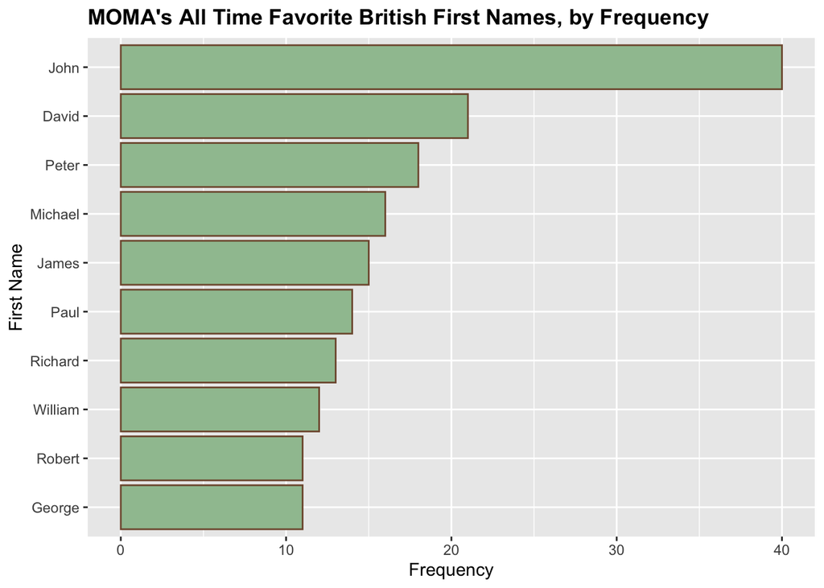

```r
# if all
all_uk <- moma_artists %>% group_by(Nationality) %>% filter(Nationality == 'British')
first_name_all_uk <- as.data.frame(word(all_uk$DisplayName,1))
colnames(first_name_all_uk) <- 'first_name'
first_name_allc_uk <- first_name_all_uk %>% group_by(first_name) %>% dplyr::summarise(Frequency = dplyr::n()) %>% arrange(Frequency)
# first name frequency
ggplot(tail(first_name_allc_uk,10), aes(fct_reorder(first_name, Frequency), Frequency)) +
  geom_bar(stat = "identity") +
  ggtitle("MOMA's All Time Favorite British First Names, by Frequency") +
  xlab("First Name") +
  geom_col(color = mycolor, fill = myfill) +
  coord_flip() +
  theme(plot.title = element_text(face = "bold"))
```

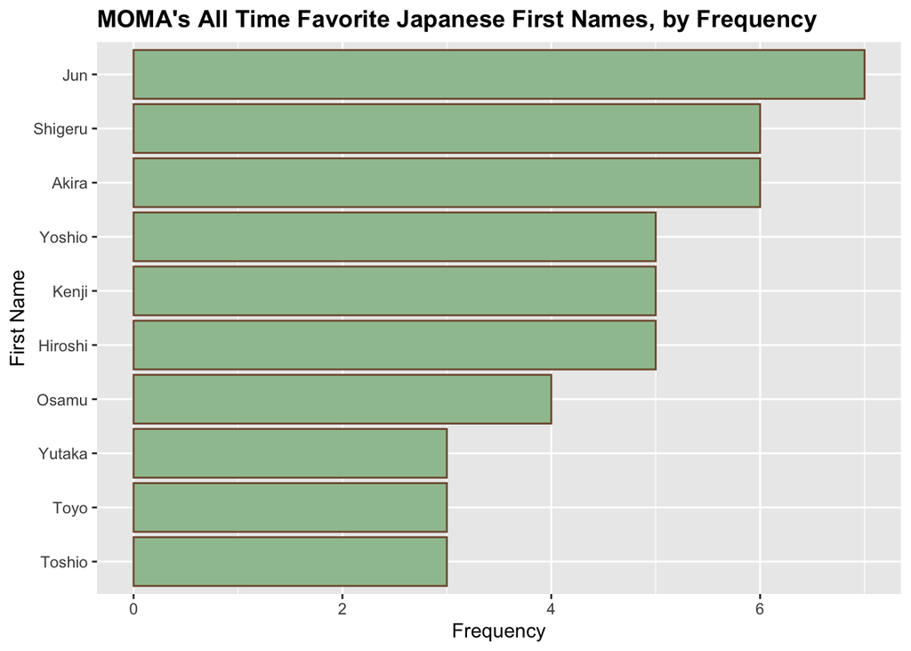

```r
# if all
all_jp <- moma_artists %>% group_by(Nationality) %>% filter(Nationality == 'Japanese')
first_name_all_jp <- as.data.frame(word(all_jp$DisplayName,1))
colnames(first_name_all_jp) <- 'first_name'
first_name_allc_jp <- first_name_all_jp %>% group_by(first_name) %>% dplyr::summarise(Frequency = dplyr::n()) %>% arrange(Frequency)
# first name frequency
ggplot(tail(first_name_allc_jp,10), aes(fct_reorder(first_name, Frequency), Frequency)) +
  geom_bar(stat = "identity") +
  ggtitle("MOMA's All Time Favorite Japanese First Names, by Frequency") +
  xlab("First Name") +
  geom_col(color = mycolor, fill = myfill) +
  coord_flip() +
  theme(plot.title = element_text(face = "bold"))
```